# Predicting bankruptcy in the telecommunications industry

### Outlier removal

```r
# Calculate residuals
residuals <- residuals(bankAIC1)

# Optionally standardize residuals
std_residuals <- rstandard(bankAIC1)

# Plot residuals against predicted values
plot(bankAIC1$fitted.values, residuals,
     xlab = "Predicted values", ylab = "Residuals",
     main = "Residual Plot")

# Identify potential outliers
outliers <- which(abs(residuals) > 2 * sd(residuals)) # Adjust the multiplier as needed


# Print indices of potential outliers
print(outliers)
```

```
##  1 27 28
##  1 27 28
```

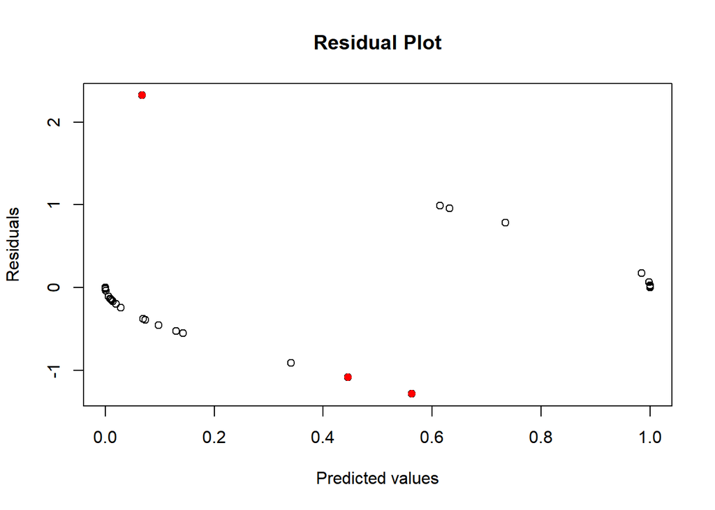

```r
# Optionally, visualize outliers on the plot
points(fitted(bankAIC1)[outliers], residuals[outliers], col = "red", pch = 16)
```

```r
# Investigate outliers further by examining corresponding data points
bankruptcy[outliers, ]
```

```
##    WC.TA RE.TA EBIT.TA S.TA BVE.BVL Bankrupt
## 1    9.3  -7.7     1.6  9.1   3.726        1
## 27   9.8 -33.8    -7.1  3.2   5.965        0
## 28  37.8 -45.4    -7.1 17.1   3.450        0
```

```r
set.seed(1234)

#Remove one outlier
bank_cleaned = bankruptcy[-1,]
detach(bankruptcy)
attach(bank_cleaned)


bank_new_full=glm(Bankrupt ~ ., data=bank_cleaned,family='binomial',maxit=500)
summary(bank_new_full)
```

```
##
## Call:
## glm(formula = Bankrupt ~ ., family = "binomial", data = bank_cleaned,
##     maxit = 500)
##
## Deviance Residuals:
##        Min          1Q      Median          3Q         Max
## -1.104e-05  -2.110e-08  -2.110e-08   2.110e-08   7.378e-06
##
## Coefficients:
##               Estimate Std. Error z value Pr(>|z|)
## (Intercept)    265.467 576281.709       0        1
## WC.TA           -4.297  12439.717       0        1
## RE.TA           -1.516   5131.146       0        1
## EBIT.TA        -17.043  35543.170       0        1
## S.TA            -2.859   7408.747       0        1
## BVE.BVL        -77.540 184903.001       0        1
##
## (Dispersion parameter for binomial family taken to be 1)
##
##     Null deviance: 6.7908e+01  on 48  degrees of freedom
## Residual deviance: 3.6353e-10  on 43  degrees of freedom
## AIC: 12
##
## Number of Fisher Scoring iterations: 30
```

### Test overall regression

The null hypothesis is that the full model does not provide a significantly better fit than than null model.

```r
gstat = bank_new_full$null.deviance - deviance(bank_new_full)
cbind(gstat, 1-pchisq(gstat,length(coef(bank_new_full))-1))
```

```
##         gstat
## [1,] 67.90801 2.791101e-13
```

Since the p-value is extremely small (< 0.05), we reject the null hypothesis.

Therefore, we conclude that the full model provides a significantly better fit to the data compared to the null model.

### Search for best model, AIC and BIC using bestglm.

```r
set.seed(1234)
library(bestglm)

#By AIC
bestAIC <- bestglm(bank_cleaned, IC="AIC",family=binomial)
```

```
## Morgan-Tatar search since family is non-gaussian.
```

```r
bestAIC
```

```
## AIC
## BICq equivalent for q in (0.144718876531243, 0.874999994439966)
## Best Model:
##               Estimate Std. Error      z value  Pr(>|z|)
## (Intercept) 193.528527 40982.6225  0.004722209 0.9962322
## WC.TA        -7.173193  1333.6792 -0.005378499 0.9957086
## RE.TA        -3.811883   843.1096 -0.004521219 0.9963926
## EBIT.TA     -21.993992  5138.6111 -0.004280143 0.9965850
## BVE.BVL     -77.898238 11828.3530 -0.006585721 0.9947454
```

```r
#By BIC
bestBIC <- bestglm(bank_cleaned, IC="BIC",family=binomial)
```

```
## Morgan-Tatar search since family is non-gaussian.
```

```r
bestBIC
```

```
## BIC
## BICq equivalent for q in (0.144718876531243, 0.874999994439966)
## Best Model:
##               Estimate Std. Error      z value  Pr(>|z|)
## (Intercept) 193.528527 40982.6225  0.004722209 0.9962322
## WC.TA        -7.173193  1333.6792 -0.005378499 0.9957086
## RE.TA        -3.811883   843.1096 -0.004521219 0.9963926
## EBIT.TA     -21.993992  5138.6111 -0.004280143 0.9965850
## BVE.BVL     -77.898238 11828.3530 -0.006585721 0.9947454
```

```r
#With outlier removed they select the same variables
bank4= glm(Bankrupt ~ RE.TA+EBIT.TA+BVE.BVL,data=bank_cleaned,family='binomial', maxit=500)
summary(bank4)
```

```
##
## Call:
## glm(formula = Bankrupt ~ RE.TA + EBIT.TA + BVE.BVL, family = "binomial",
##     data = bank_cleaned, maxit = 500)
##
## Deviance Residuals:
##      Min        1Q    Median        3Q       Max
## -1.77491  -0.06042   0.00000   0.00943   1.84492
##
## Coefficients:
##             Estimate Std. Error z value Pr(>|z|)
## (Intercept) -0.09166    1.47135  -0.062   0.9503
## RE.TA       -0.08229    0.04230  -1.945   0.0517 .
## EBIT.TA     -0.26783    0.15854  -1.689   0.0912 .
## BVE.BVL     -1.21810    0.76536  -1.592   0.1115
## ---
## Signif. codes:  0 '***' 0.001 '**' 0.01 '*' 0.05 '.' 0.1 ' ' 1
##
## (Dispersion parameter for binomial family taken to be 1)
##
##     Null deviance: 67.9080  on 48  degrees of freedom
## Residual deviance:  9.3841  on 45  degrees of freedom
## AIC: 17.384
##
## Number of Fisher Scoring iterations: 10
```

```r
exp(coef(bank3)[-1])
```

```
##     RE.TA   EBIT.TA   BVE.BVL
## 0.9452862 0.8456655 0.5327273
```

- RE.TA: A one-unit increase in RE.TA, the odds of the outcome (Bankrupt) decreases by approximately 5.5% (0.945-1).
- EBIT.TA: A one-unit increase in EBIT.TA, the odds of the outcome (Bankrupt) decreases by approximately 15.4% (0.846-1).
- BVE.BVL: A one-unit increase in BVE.BVL, the odds of the outcome (Bankrupt) decreases by approximately 46.7% (0.533-1).

```r
exp(coef(bank4)[-1])
```

```
##     RE.TA   EBIT.TA   BVE.BVL
## 0.9210091 0.7650371 0.2957930
```

- RE.TA: A one-unit increase in RE.TA, the odds of the outcome (Bankrupt) decreases by approximately 7.9% (0.921-1).
- EBIT.TA: A one-unit increase in EBIT.TA, the odds of the outcome (Bankrupt) decreases by approximately 23.5% (0.765-1).
- BVE.BVL: A one-unit increase in BVE.BVL, the odds of the outcome (Bankrupt) decreases by approximately 70.4% (0.296-1).

In both models, an increase in EBIT.TA and BVE.BVL is associated with lower odds of bankruptcy. This suggests that companies with higher earnings relative to their total assets are less likely to go bankrupt.

### Apply Stepwise Regression

#### Forward

```r
full = glm(Bankrupt ~ ., data=bank_cleaned,family='binomial'(link = "logit"),maxit=500)
minimum = glm(Bankrupt ~ 1, data=bank_cleaned,family='binomial'(link = "logit"), maxit=500)
n= nrow(bank_cleaned)
#AIC
fwd_AIC<-step(minimum,
     scope = list(lower=minimum,upper = full),
     direction = "forward", trace=F)
fwd_AIC
```

```
##
## Call:  glm(formula = Bankrupt ~ RE.TA + BVE.BVL + EBIT.TA + WC.TA, family = binomial(link = "logit"),
##     data = bank_cleaned, maxit = 500)
##
## Coefficients:
## (Intercept)        RE.TA      BVE.BVL      EBIT.TA        WC.TA
##     255.413       -5.152     -103.614      -28.983       -9.542
##
## Degrees of Freedom: 48 Total (i.e. Null);  44 Residual
## Null Deviance:       67.91
## Residual Deviance: 4.249e-10     AIC: 10
```

```r
#BIC
fwd_BIC<-step(minimum,
     scope = list(lower=minimum,upper = full),
     direction = "forward", trace=F, k=log(n))
fwd_BIC
```

```
##
## Call:  glm(formula = Bankrupt ~ RE.TA + BVE.BVL + EBIT.TA + WC.TA, family = binomial(link = "logit"),
##     data = bank_cleaned, maxit = 500)
##
## Coefficients:
## (Intercept)        RE.TA      BVE.BVL      EBIT.TA        WC.TA
##     255.413       -5.152     -103.614      -28.983       -9.542
##
## Degrees of Freedom: 48 Total (i.e. Null);  44 Residual
## Null Deviance:       67.91
## Residual Deviance: 4.249e-10     AIC: 10
```

Both AIC and BIC select the same: RE.TA, BVE.BVL, EBIT.TA, WC.TA

#### Backward

```r
#backwards via AIC
bck_AIC<-step(full, scope = list(lower=minimum, upper = full), direction = "backward", trace = F)
bck_AIC
```

```
##
## Call:  glm(formula = Bankrupt ~ WC.TA + RE.TA + EBIT.TA + BVE.BVL, family = binomial(link = "logit"),
##     data = bank_cleaned, maxit = 500)
##
## Coefficients:
## (Intercept)        WC.TA        RE.TA      EBIT.TA      BVE.BVL
##     255.413       -9.542       -5.152      -28.983     -103.614
##
## Degrees of Freedom: 48 Total (i.e. Null);  44 Residual
## Null Deviance:       67.91
## Residual Deviance: 4.249e-10     AIC: 10
```

```r
#Backwards via BIC
bck_BIC<-step(full, scope = list(lower=minimum, upper = full), direction = "backward", trace = F, k=log(n))
bck_BIC
```

```
##
## Call:  glm(formula = Bankrupt ~ WC.TA + RE.TA + EBIT.TA + BVE.BVL, family = binomial(link = "logit"),
##     data = bank_cleaned, maxit = 500)
##
## Coefficients:
## (Intercept)        WC.TA        RE.TA      EBIT.TA      BVE.BVL
##     255.413       -9.542       -5.152      -28.983     -103.614
##
## Degrees of Freedom: 48 Total (i.e. Null);  44 Residual
## Null Deviance:       67.91
## Residual Deviance: 4.249e-10     AIC: 10
```

Backwards stepwsise regression selected the same 4: WC.TA, RE.TA, EBIT.TA, BVE.BVL

#### Both Forward and Backward

```r
set.seed(1234)
bth_AIC<-step(minimum, scope = list(lower=minimum, upper = full), direction = "both", trace=F)
bth2_AIC<-step(full, scope = list(lower=minimum, upper = full), direction = "both", trace = F)

bth_BIC<-step(minimum, scope = list(lower=minimum, upper = full), direction = "both", trace=F,k=log(n))
bth2_BIC<-step(full, scope = list(lower=minimum, upper = full), direction = "both", trace = F,k=log(n))

bth_AIC
```

```
##
## Call:  glm(formula = Bankrupt ~ RE.TA + BVE.BVL + EBIT.TA + WC.TA, family = binomial(link = "logit"),
##     data = bank_cleaned, maxit = 500)
##
## Coefficients:
## (Intercept)        RE.TA      BVE.BVL      EBIT.TA        WC.TA
##     255.413       -5.152     -103.614      -28.983       -9.542
##
## Degrees of Freedom: 48 Total (i.e. Null);  44 Residual
## Null Deviance:       67.91
## Residual Deviance: 4.249e-10     AIC: 10
```

```r
bth_BIC
```

```
##
## Call:  glm(formula = Bankrupt ~ RE.TA + BVE.BVL + EBIT.TA + WC.TA, family = binomial(link = "logit"),
##     data = bank_cleaned, maxit = 500)
##
## Coefficients:
## (Intercept)        RE.TA      BVE.BVL      EBIT.TA        WC.TA
##     255.413       -5.152     -103.614      -28.983       -9.542
##
## Degrees of Freedom: 48 Total (i.e. Null);  44 Residual
## Null Deviance:       67.91
## Residual Deviance: 4.249e-10     AIC: 10
```

```r
bank6=glm(Bankrupt ~ WC.TA+RE.TA+EBIT.TA+BVE.BVL, data=bank_cleaned,family='binomial'(link = "logit"), maxit=500)
summary(bank6)
```

```
##
## Call:
## glm(formula = Bankrupt ~ WC.TA + RE.TA + EBIT.TA + BVE.BVL, family = binomial(link = "logit"),
##     data = bank_cleaned, maxit = 500)
##
## Deviance Residuals:
##        Min          1Q      Median          3Q         Max
## -1.399e-05  -2.110e-08  -2.110e-08   2.110e-08   1.183e-05
##
## Coefficients:
##               Estimate Std. Error z value Pr(>|z|)
## (Intercept)    255.413 728539.823       0        1
## WC.TA           -9.542  23920.936       0        1
## RE.TA           -5.152  15669.825       0        1
## EBIT.TA        -28.983  90578.211       0        1
## BVE.BVL       -103.614 225264.760       0        1
##
## (Dispersion parameter for binomial family taken to be 1)
##
##     Null deviance: 6.7908e+01  on 48  degrees of freedom
## Residual deviance: 4.2489e-10  on 44  degrees of freedom
## AIC: 10
##
## Number of Fisher Scoring iterations: 31
```

WC.TA, RE.TA, EBIT.TA, BVE.BVL

### Regularized Regression

#### scale variables

```r
set.seed(1234)
bank_var<-scale(bank_cleaned[,-6])
```

### Ridge Regression

```r
library(glmnet)
set.seed(49)


# Code to conduct ridge regression, and find optimal lambda
# the regularization parameter that minimizes the cross-validated error in the ridge regression model.
cv.ridge = cv.glmnet(bank_var, Bankrupt,family='binomial', alpha=0,type.measure ='class', nfolds=10)

cv.ridge$lambda.min
```

```
## [1] 0.1982858
```

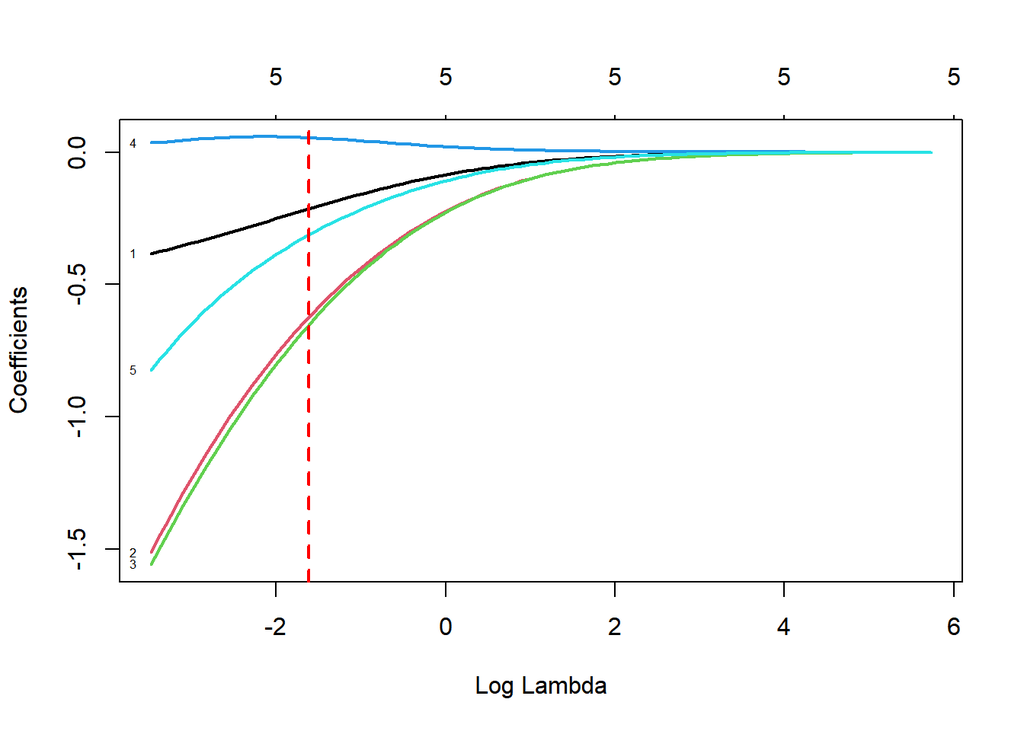

```r
ridge.mod = glmnet(bank_var, Bankrupt,family='binomial',alpha=0, nlambda =100)

#plot the ridge coef  path
# a visual representation of how the coefficients change in response to different levels of regularization (lambda is the amount of regularization applied to the coefficients). The lambda is a tuning parameter that determines the strength of regularization (penalty) -> more shrinkage of coefficients towards zero.
plot(ridge.mod, xvar = "lambda", label = TRUE, lwd = 2)
abline(v=log(cv.ridge$lambda.min),col='red',lty = 2,lwd=2)
```

```r
coef(ridge.mod, s = cv.ridge$lambda.min)
```

```
## 6 x 1 sparse Matrix of class "dgCMatrix"
##                      s1
## (Intercept)  0.03863309
## WC.TA       -0.21419400
## RE.TA       -0.62421022
## EBIT.TA     -0.65363519
## S.TA         0.05457429
## BVE.BVL     -0.31308629
```

### Lasso Regression

```r
set.seed(49)

# Code to conduct lasso regression, and find optimal lambda
cv.lasso = cv.glmnet(bank_var, Bankrupt,family='binomial', alpha=1,type.measure ='class', nfolds=10)

cv.lasso$lambda.min
```

```
## [1] 0.03307606
```

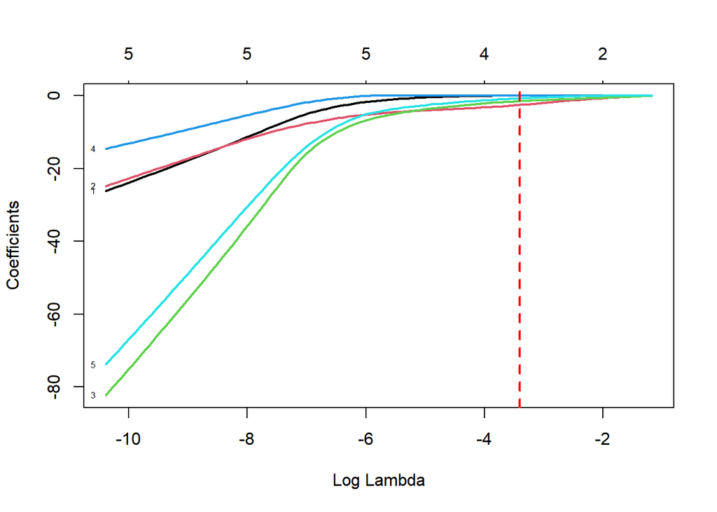

```r
lasso.mod = glmnet(bank_var,Bankrupt,family='binomial',alpha=1, nlambda=100)

#plot the lasso coef  path
plot(lasso.mod, xvar = "lambda", label = TRUE, lwd = 2)
abline(v=log(cv.lasso$lambda.min),col='red',lty = 2,lwd=2)
```

```r
coef(lasso.mod, s = cv.lasso$lambda.min)
```

```
## 6 x 1 sparse Matrix of class "dgCMatrix"
##                     s1
## (Intercept)  0.5728627
## WC.TA        .
## RE.TA       -2.4870902
## EBIT.TA     -1.4667460
## S.TA         .
## BVE.BVL     -0.7025255
```

### Elastic Net Regression using GLMNET

```r
set.seed(49)

# Code to conduct elastic net regression, and find optimal lamb

cv.elastic = cv.glmnet(bank_var,  Bankrupt,family='binomial', alpha=0.5,type.measure ='class', nfolds=10)

cv.elastic$lambda.min
```

```
## [1] 0.0112945
```

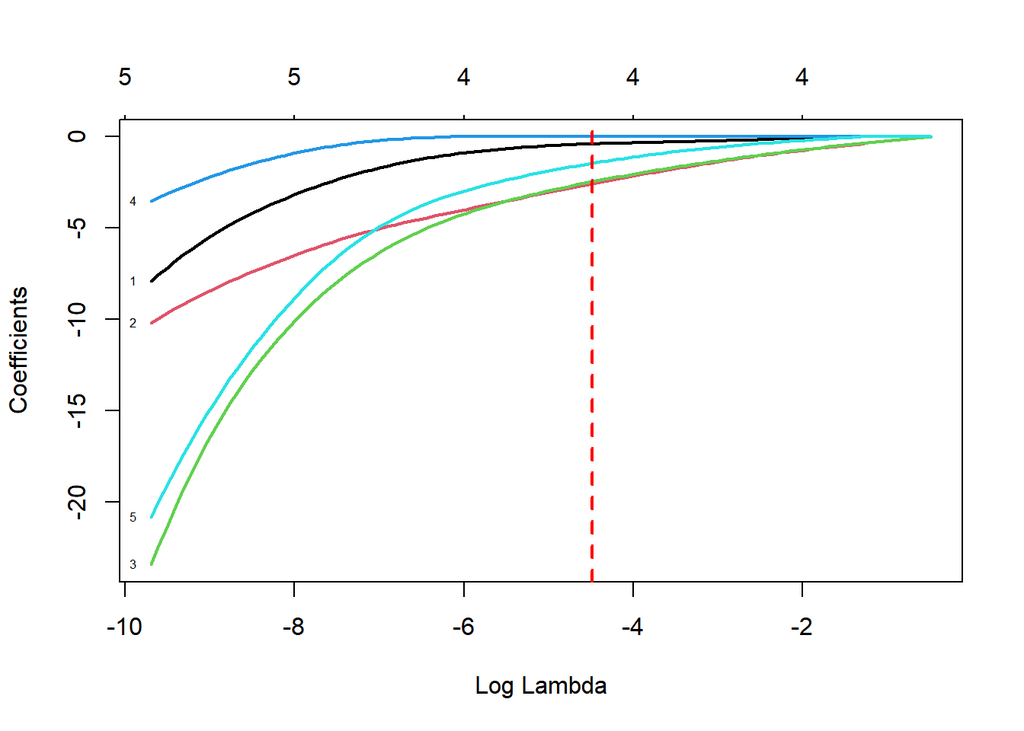

```r
elastic.mod = glmnet(bank_var,  Bankrupt,family='binomial',alpha=0.5, nlambda=100)

#plot the elastic net coef  path
plot(elastic.mod, xvar = "lambda", label = TRUE, lwd = 2)
abline(v=log(cv.elastic$lambda.min),col='red',lty = 2,lwd=2)
```

```r
coef(elastic.mod, s = cv.elastic$lambda.min)
```

```
## 6 x 1 sparse Matrix of class "dgCMatrix"
##                     s1
## (Intercept)  0.8168453
## WC.TA       -0.3861189
## RE.TA       -2.5655168
## EBIT.TA     -2.4554504
## S.TA         .
## BVE.BVL     -1.4486946
```